# X-Men and the Bechdel Test

Jo Hardin

6/30/2020

I wasn’t planning to spend a lot of time on this, as I don’t really know much or care much about comic books, and life calls in lots of ways! But I wanted to keep practicing my tidy skills, and the hour I spent working on these data paid off!

I thought it might be interesting to see how often some of the issues focused on characters experiencing different actions, broken down by Bechdel Test status. I tried `geom_hist` and `geom_bar`, but because of the count default, I wasn’t really seeing a good comparison (there are a lot more issues which pass the Bechdel Test than don’t).

Through some sleuthing, I was able to find the `stat_count` function which uses `y=..prop..` in `aes()` to determine the y-axis. I also messed with the colors a bit. And though there aren’t any important results with respect to the comic books, I was able to create the exact plots I wanted.

Also, shout out to Malcolm Barrett (https://twitter.com/malco_barrett) who is doing so many great things in the #rstats community!! Thanks, Malcolm.

## Loading in the Data

```r
comic_bechdel <- readr::read_csv('https://raw.githubusercontent.com/rfordatascience/tidytuesday/master/data/2020/2020-06-30/comic_bechdel.csv')

character_visualization <- readr::read_csv('https://raw.githubusercontent.com/rfordatascience/tidytuesday/master/data/2020/2020-06-30/character_visualization.csv')

characters <- readr::read_csv('https://raw.githubusercontent.com/rfordatascience/tidytuesday/master/data/2020/2020-06-30/characters.csv')

xmen_bechdel <- readr::read_csv('https://raw.githubusercontent.com/rfordatascience/tidytuesday/master/data/2020/2020-06-30/xmen_bechdel.csv')

covers <- readr::read_csv('https://raw.githubusercontent.com/rfordatascience/tidytuesday/master/data/2020/2020-06-30/covers.csv')

issue_collaborators <- readr::read_csv('https://raw.githubusercontent.com/rfordatascience/tidytuesday/master/data/2020/2020-06-30/issue_collaborators.csv')

locations <- readr::read_csv('https://raw.githubusercontent.com/rfordatascience/tidytuesday/master/data/2020/2020-06-30/locations.csv')
```

```r
xmen <- full_join(xmen_bechdel, characters, by = "issue")
```

```r
temp <- xmen %>%
  filter(!is.na(character)) %>%
  group_by(issue, pass_bechdel) %>%
  summarize(tornclothes = sum(clothing_torn), dead = sum(declared_dead), quits = sum(quits_team),
            kiss = sum(!is.na(kiss_with_which_character)),
            hug = sum(!is.na(hugging_with_which_character)),
            date = sum(!is.na(on_a_date_with_which_character)),
            dance = sum(!is.na(dancing_with_which_character)))

temp %>% group_by(pass_bechdel) %>% summarise(n())
```

```
## # A tibble: 2 x 2
##   pass_bechdel `n()`
##   <chr>        <int>
## 1 no              42
## 2 yes            148
```

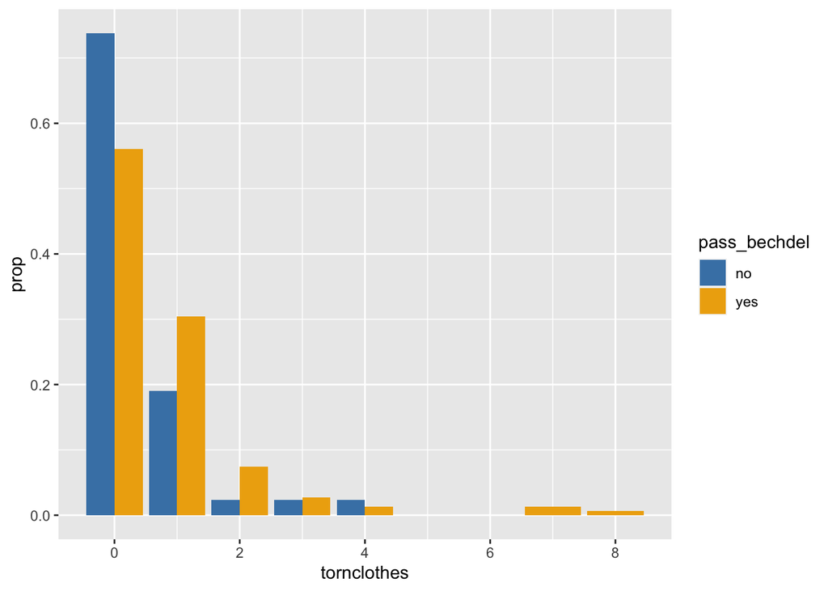

```r
temp %>%
  ggplot() +
  stat_count(aes(x=tornclothes, fill = pass_bechdel, group = pass_bechdel,
                      y = ..prop..), position = "dodge") +
  scale_fill_manual(values = c("steelblue", "darkgoldenrod2" ))
```

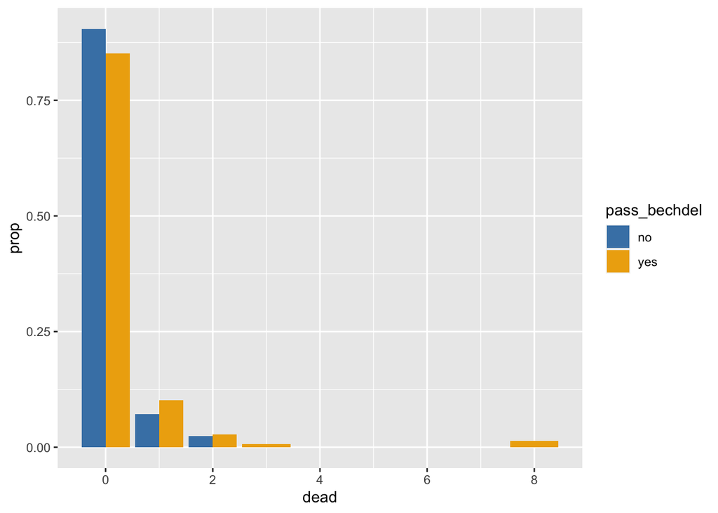

```r
temp %>%
  ggplot() +
  stat_count(aes(x=dead, fill = pass_bechdel, group = pass_bechdel,
                      y = ..prop..), position = "dodge") +
  scale_fill_manual(values = c("steelblue", "darkgoldenrod2" ))
```

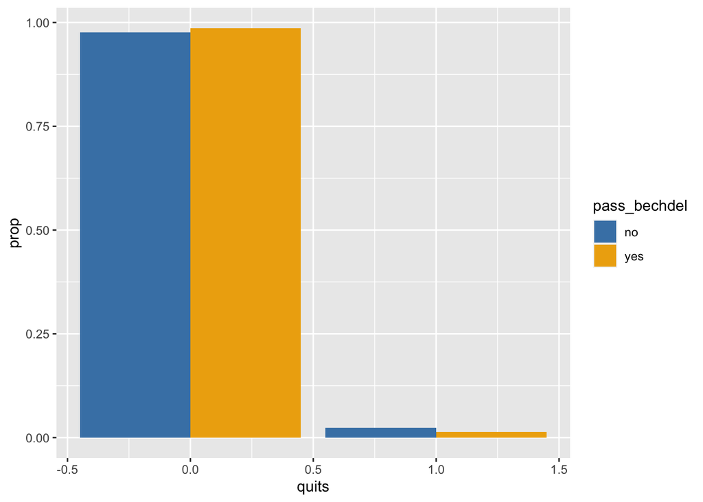

```r
temp %>%
  ggplot() +
  stat_count(aes(x=quits, fill = pass_bechdel, group = pass_bechdel,
                      y = ..prop..), position = "dodge") +
  scale_fill_manual(values = c("steelblue", "darkgoldenrod2" ))
```

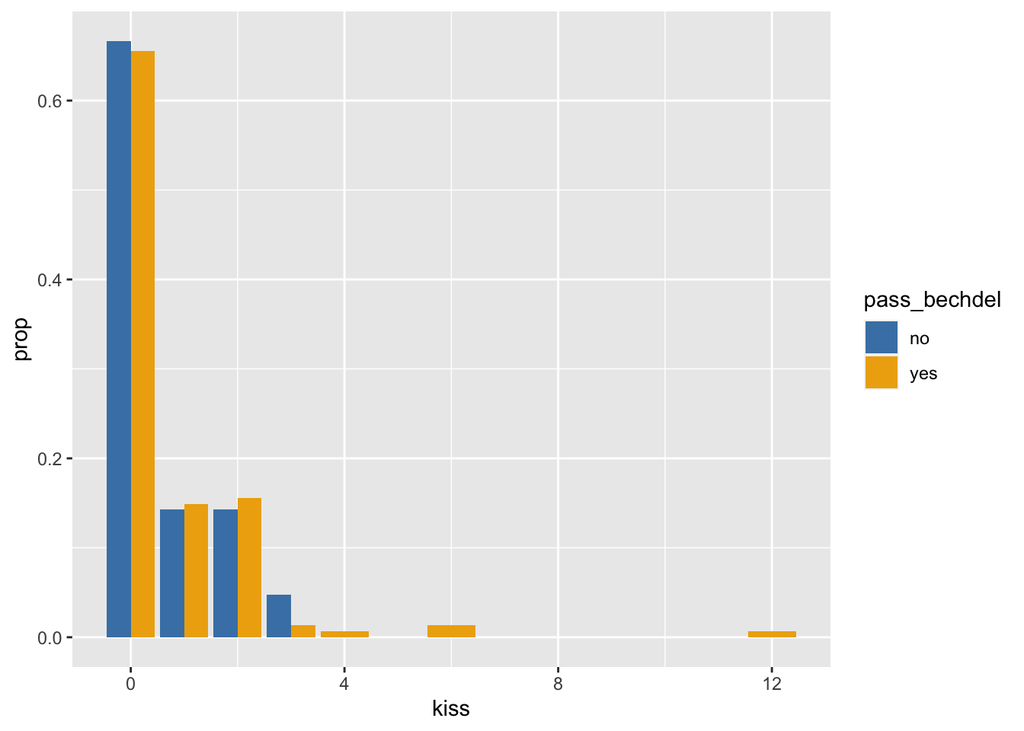

```r
temp %>%
  ggplot() +
  stat_count(aes(x=kiss, fill = pass_bechdel, group = pass_bechdel,
                      y = ..prop..), position = "dodge") +
  scale_fill_manual(values = c("steelblue", "darkgoldenrod2" ))
```

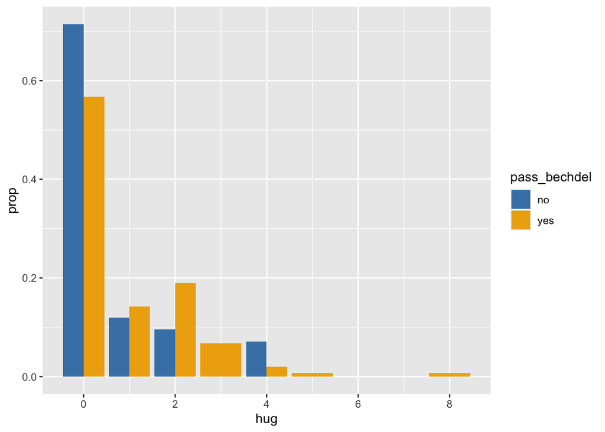

```r
temp %>%
  ggplot() +
  stat_count(aes(x=hug, fill = pass_bechdel, group = pass_bechdel,
                      y = ..prop..), position = "dodge") +
  scale_fill_manual(values = c("steelblue", "darkgoldenrod2" ))
```

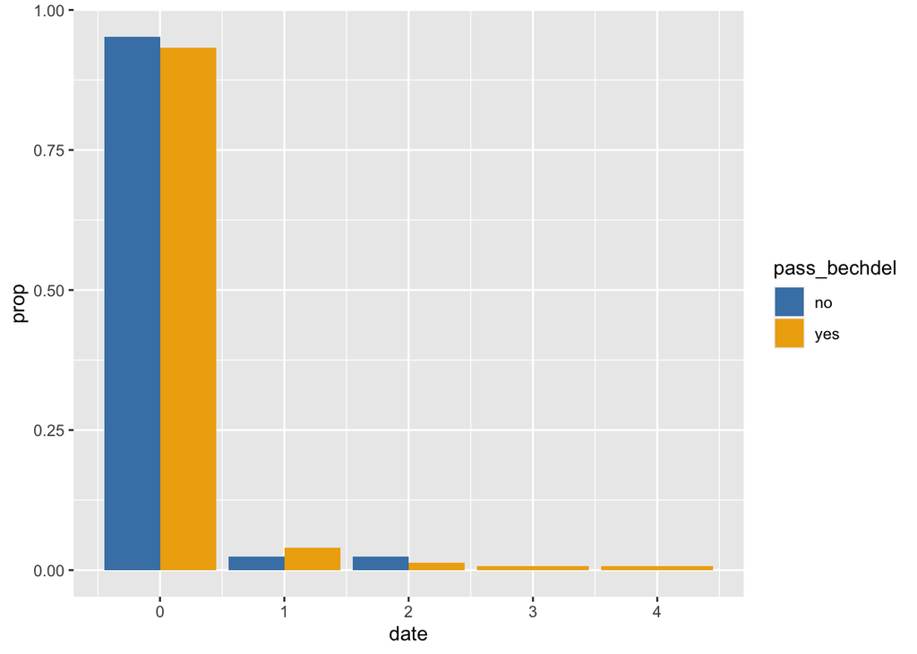

```r
temp %>%
  ggplot() +
  stat_count(aes(x=date, fill = pass_bechdel, group = pass_bechdel,
                      y = ..prop..), position = "dodge") +
  scale_fill_manual(values = c("steelblue", "darkgoldenrod2" ))
```

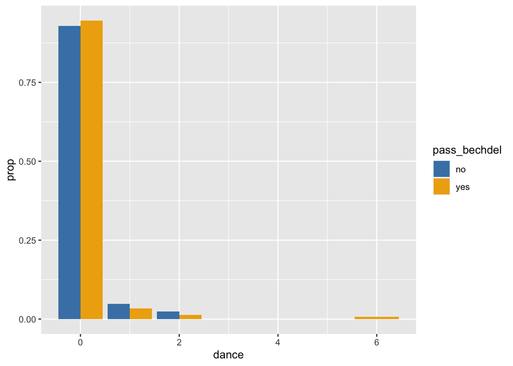

```r
temp %>%
  ggplot() +
  stat_count(aes(x=dance, fill = pass_bechdel, group = pass_bechdel,
                      y = ..prop..), position = "dodge") +
  scale_fill_manual(values = c("steelblue", "darkgoldenrod2" ))
```